# Estero Bay Shell Height Sample Size

CZ325 Task 3: Evaluation of sample size to assess managed-area-level trends Deliverable 3a:

```r
library(cmdstanr)
library(rstan)
library(posterior)
library(bayesplot)
library(magrittr)
library(tidyverse)
library(spBayes)
library(MBA)
#library(geoR)
library(fields)
library(sp)
library(maptools)
library(rgdal)
library(classInt)
library(lattice)
library(RColorBrewer)

rstan_options(auto_write = TRUE)
options(mc.cores = parallel::detectCores())

library(leaflet)
```

Look at some real data

```r
oysterraw_2022_06_30 = readRDS("oysterraw_2022-06-30_wcoords.rds")
```

UniversalReefID

First, we look at shell height as a response

```r
oysterraw_2022_06_30 %>% dplyr::select(ShellHeight_mm, ManagedAreaName,SampleDate,ShellHeight_mm, ObsIndex, Latitude, Longitude,UniversalReefID) %>% na.omit() %>% filter(ManagedAreaName == "Estero Bay Aquatic Preserve") -> Estero_Bay_shell_height
```

Looks like 58 sites

```r
Estero_Bay_shell_height %>% group_by(UniversalReefID) %>% summarize( n = n())
```

[output not shown]

use average UniversalReefID lat lon for position of UniversalReefID This data set has multiple shell height observations per UniversalReefID site ShellHeight_mm ManagedAreaName SampleDate ObsIndex Latitude Longitude UniversalReefID mean_lat mean_lon DaysSince group

```r
Estero_Bay_shell_height %>% dplyr::select( UniversalReefID, Latitude,Longitude) %>%  group_by(UniversalReefID) %>% summarize( mean_lat = mean(Latitude), mean_lon = mean(Longitude) ) %>% distinct() -> UI2LL
left_join(Estero_Bay_shell_height,UI2LL,by = join_by(UniversalReefID)) %>% mutate(DaysSince = (SampleDate - min(SampleDate))/3600/24 ) %>% group_by(UniversalReefID) %>% mutate( group = cur_group_id()) -> Estero_Bay_Data
```

Fit the Baysian model for Mean shell heights that vary by space Total execution time: 3893.9/3600 = 1.08

```r
Data = list( N =  nrow(Estero_Bay_Data)
             ,  y = Estero_Bay_Data$ShellHeight_mm
             , x = as.numeric(Estero_Bay_Data$DaysSince) # this can be used for growth calculations
             , G = max(Estero_Bay_Data$group)
             , group = Estero_Bay_Data$group
             , positions = (Estero_Bay_Data %>% dplyr::select(mean_lon, mean_lat, group) %>% distinct() %>% arrange(group))[,c("mean_lon","mean_lat")]
             )


spatial_mean_RE.mod <- cmdstan_model("spatial_mean_RE.stan")

 spatial_mean_RE.EsteroBay.Shell_Height =  spatial_mean_RE.mod$sample(
    data = Data,
    seed = 1111,
    chains = 4, # 8
    parallel_chains = 4, # 8
    refresh = 1000,
    iter_warmup = 5000,
    iter_sampling = 5000,
    thin =  1
    #, adapt_delta = 0.99
  )
```

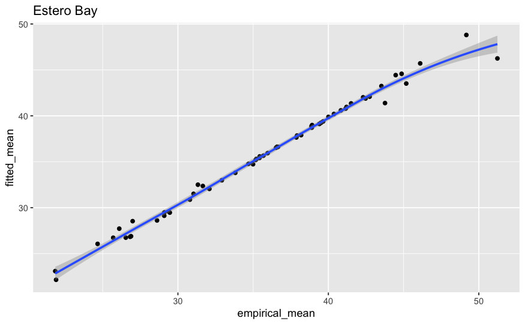

```r
data.frame(empirical_mean = (Estero_Bay_Data %>% group_by(UniversalReefID) %>% summarize( empirical_mean = mean(ShellHeight_mm)))$empirical_mean, fitted_mean = spatial_mean_RE.EsteroBay.Shell_Height$summary("site_mean")$mean) %>%
  ggplot(aes(x = empirical_mean, y = fitted_mean)) + geom_point() + geom_smooth() + ggtitle("Estero Bay")
```

Standard Deviation of posterior distribution of mean shell_height_mm estimate per site as a function of sample size

```r
sd_by_sample_size = data.frame(sample_size = (Estero_Bay_Data %>% group_by(UniversalReefID) %>% summarize( n = n()))$n, sd = spatial_mean_RE.EsteroBay.Shell_Height$summary("site_mean")$sd)
```

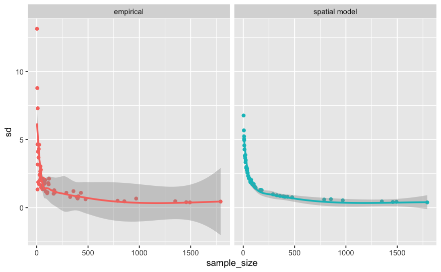

```r
rbind(Estero_Bay_Data %>% group_by(UniversalReefID) %>% summarize( sample_size = n(), sd = sd(ShellHeight_mm)/sqrt(n())) %>% dplyr::select(sample_size, sd) %>% mutate(method = "empirical"),
sd_by_sample_size %>% mutate(method = "spatial model")) %>% ggplot(aes(x = sample_size, y = sd, color = method)) + geom_point() + geom_smooth( show.legend = FALSE) + facet_wrap(~method) + theme(legend.position="none")
```

```r
ggsave("sd_by_sample_size.png", height = 5)
```

Density of shell heights

```r
Estero_Bay_Data %>% ggplot(aes(x = ShellHeight_mm)) + geom_histogram()
```

[output not shown]

Regular grid inside the convex hull of the original points

```r
grid = spsample(Polygon(Data$positions[chull(Data$positions),]), n = 256, type = "regular")
new_positions = grid@coords
```

Prediction: draw from the relevant posterior distributions

```r
source("SpatialPredictionUtilities.R")
alpha_posterior = spatial_mean_RE.EsteroBay.Shell_Height$draws("sigma", format = "draws_matrix") # 4 chains 5000 draws after 5000 warmup
rho_posterior = spatial_mean_RE.EsteroBay.Shell_Height$draws("length_scale", format = "draws_matrix")
obs_gp_function_posterior = spatial_mean_RE.EsteroBay.Shell_Height$draws("gp_function", format = "draws_matrix")
obs_distances =  my_calc_point_distances(Data$positions)
pred_distances =  my_calc_point_distances(new_positions)
obs_to_pred_distances = my_calc_point_distances(Data$positions, new_positions)
global_mean_posterior = spatial_mean_RE.EsteroBay.Shell_Height$draws("global_mean", format = "draws_matrix")
```

```r
mean_preds <- matrix(NA, nrow = 100, ncol = NROW(new_positions))
for(i in 1:NROW(gp_preds)){
  #cat('Processing posterior draw', i, 'of 5...\n')
  mean_preds[i,] <- predict_mean(as.numeric(global_mean_posterior[i,]), obs_distances = obs_distances,
                             pred_distances = pred_distances,
                             obs_to_pred_distances = obs_to_pred_distances,
                             obs_gp_function = as.vector(as.matrix(obs_gp_function_posterior[i,])),
                             alpha = alpha_posterior[i],
                             rho = rho_posterior[i])
}
```

plot of sd of estimates

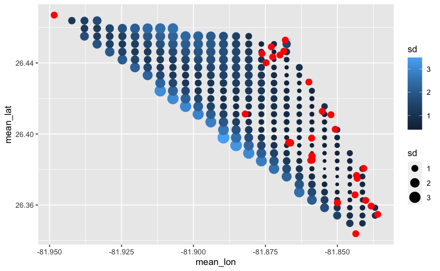

```r
data.frame(mean_lon = new_positions[,1], mean_lat = new_positions[,2], sd = apply(mean_preds, 2, sd) ) %>% ggplot(aes(x = mean_lon, y = mean_lat, color = sd, size = sd)) + geom_point() + geom_point(data = Data$positions, aes(x = mean_lon, y = mean_lat, size = 1), color = "red", show.legend = FALSE)
```

```r
ggmap(get_map(location = as.data.frame(new_positions), zoom = 12))+ geom_point( data = as.data.frame(new_positions), aes(x =x1, y = x2 , color = apply(mean_preds,2,sd)),size = apply(mean_preds,2,sd)) + geom_point( data = Data$positions, aes(x =mean_lon, y = mean_lat ), color = "red")  +  guides(color = guide_legend(title = "sd"))
ggsave("Estero Bay grid plot.png")
```

```r
m <- leaflet() %>%
  addTiles() %>%  # Add default OpenStreetMap map tiles
  addCircleMarkers(lng=Data$positions$mean_lon, lat=Data$positions$mean_lat, color = "red", radius = 0.5) %>%  # Add default OpenStreetMap map tiles
  addCircleMarkers(lng=new_positions[,1], lat=new_positions[,2], radius = 4*apply(mean_preds,2,sd))
m
```

[interactive chart not shown]

Prediction at additional oyster sites

```r
hey = cz325_GRMAPandEBAPoysters[ cz325_GRMAPandEBAPoysters$METADATA == "oysters_estero_2021","geometry"]
#get centroids
oyster_positions = as.data.frame(st_coordinates(st_centroid(hey$geometry)))
names(oyster_positions) = c("lon","lat")

obs_to_pred_distances = my_calc_point_distances(Data$positions, oyster_positions)
pred_distances =  my_calc_point_distances(oyster_positions)
oyster_mean_preds <- matrix(NA, nrow = 100, ncol = NROW(oyster_positions))
for(i in 1:NROW(gp_preds)){
  #cat('Processing posterior draw', i, 'of 5...\n')
  oyster_mean_preds[i,] <- predict_mean(as.numeric(global_mean_posterior[i,]), obs_distances = obs_distances,
                             pred_distances = pred_distances,
                             obs_to_pred_distances = obs_to_pred_distances,
                             obs_gp_function = as.vector(as.matrix(obs_gp_function_posterior[i,])),
                             alpha = alpha_posterior[i],
                             rho = rho_posterior[i])
}
```

[figure not shown]

```r
ggmap(get_map(location = as.data.frame(oyster_positions), zoom = 12))+ geom_point( data = as.data.frame(oyster_positions), aes(x =lon, y = lat , color = apply(oyster_mean_preds,2,sd)),size = apply(oyster_mean_preds,2,sd)) + geom_point( data = Data$positions, aes(x =mean_lon, y = mean_lat ), color = "red")  +  guides(color = guide_legend(title = "sd"))
```

```r
ggsave("OysterMap.png")
```

Leaflet version

```r
mO <- leaflet() %>%
  addTiles() %>%  # Add default OpenStreetMap map tiles
  addCircleMarkers(lng=oyster_positions$lon, lat=oyster_positions$lat, radius = 4*apply(oyster_mean_preds,2,sd))  %>%
  addCircleMarkers(lng=Data$positions$mean_lon, lat=Data$positions$mean_lat, color = "red", radius = 0.5)
mO
```

```r
plot(density(apply(mean_preds,2,sd)))
```

Convert to sample sizes for given sd

```r
fit = loess(sample_size ~ sd, sd_by_sample_size)
```

Effective sample sizes: for each predicted sd, compute the effective sample sizes

```r
n_hat = as.numeric(predict(fit, newdata = data.frame(sd = apply(mean_preds, 2, sd))))
data.frame(mean_lon = new_positions[,1], mean_lat = new_positions[,2], n_hat ) %>% ggplot(aes(x = mean_lon, y = mean_lat, color = n_hat, size = n_hat)) + geom_point() + geom_point(data = Data$positions, aes(x = mean_lon, y = mean_lat, size = 1), color = "red")
```

[output not shown]

```r
ggmap(get_map(location = as.data.frame(new_positions), zoom = 12))+ geom_point( data = as.data.frame(new_positions), aes(x =x1, y = x2 , color = n_hat),size = 0.002*n_hat) + geom_point( data = Data$positions, aes(x =mean_lon, y = mean_lat ), color = "red")  +  guides(color = guide_legend(title = "effective sample sizes"))
```

```r
m1 <- leaflet() %>%
  addTiles() %>%  # Add default OpenStreetMap map tiles
  addCircleMarkers(lng=Data$positions$mean_lon, lat=Data$positions$mean_lat, color = "red", radius = 0.005*(Estero_Bay_Data %>% count(UniversalReefID))$n, label = (Estero_Bay_Data %>% count(UniversalReefID))$n) %>%  # Add default OpenStreetMap map tiles
  addCircleMarkers(lng=new_positions$x1, lat=new_positions$x2, radius = 0.005*n_hat, label = round(n_hat))
m1
```

[interactive chart not shown]

Proportional inclusion probabilities Do sd of average size: nonUniform sampling using GRTS # adding prediction uncertainty to sampling

```r
require(spsurvey)
oyster.positions.sd.sf =st_as_sf(data.frame(oyster_positions, sd = apply(oyster_mean_preds,2,sd), var  = apply(oyster_mean_preds,2,var)), coords = c("lon","lat"), crs =  st_crs("WGS84"))

GRTS_nonuniform_sampling_results = data.frame()
for( sample_size in 2:50)
  {
  for( iterations in 1:100){

    tmp_new_positions = as.data.frame(st_coordinates(grts(oyster.positions.sd.sf,n_base = sample_size, projcrs_check = FALSE, aux_var = "var")$sites_base))

    #tmp_new_positions = runif_in_polygon(n = sample_size, vertices = as.matrix(Data$positions[chull(Data$positions),]))
obs_to_pred_distances = my_calc_point_distances(Data$positions, tmp_new_positions)
pred_distances =  my_calc_point_distances(tmp_new_positions)
tmp_mean_preds <- matrix(NA, nrow = 100, ncol = NROW(tmp_new_positions))
for(i in 1:NROW(tmp_mean_preds)){
  #cat('Processing posterior draw', i, 'of 5...\n')
  tmp_mean_preds[i,] <- predict_mean(as.numeric(global_mean_posterior[i,]), obs_distances = obs_distances,
                             pred_distances = pred_distances,
                             obs_to_pred_distances = obs_to_pred_distances,
                             obs_gp_function = as.vector(as.matrix(obs_gp_function_posterior[i,])),
                             alpha = alpha_posterior[i],
                             rho = rho_posterior[i])
       }
  GRTS_nonuniform_sampling_results = rbind(GRTS_nonuniform_sampling_results, data.frame(sample_size = sample_size, sd = sd(apply(tmp_mean_preds,1,mean))))
  }
}
```

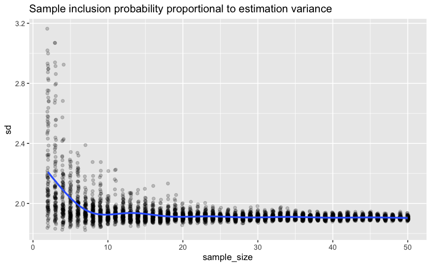

```r
GRTS_nonuniform_sampling_results %>% ggplot(aes(x = sample_size, y = sd)) + geom_jitter(width = 0.1, alpha = 0.2)  + geom_smooth() + ggtitle("Sample inclusion probability proportional to estimation variance")
ggsave("sd_by_spatial_sampl.png", height = 5)
```

Incorporating Salinity as a covariate

```r
cz325_t3_salinity = read.csv("cz325_t3_salinity.csv")
cz325_t3_salinity %>% filter( ManagedAreaName == "Estero Bay Aquatic Preserve") -> EsteroBay_cz325_t3_salinity
```

```r
EsteroBay_cz325_t3_salinity %>% dplyr::select(OriginalLongitude,OriginalLatitude) -> salinity_locations
EsteroBay_cz325_t3_salinity %>% dplyr::select(OriginalLongitude,OriginalLatitude, ResultValue ) -> salinity_values
```

For each point in original data find closest position and corresponding salinity

```r
orig_to_salinity_distances = my_calc_point_distances(Data$positions, salinity_locations)
original_salinity_values = salinity_values$ResultValue[apply(orig_to_salinity_distances,1,which.min)]

oyster_to_salinity_distances = my_calc_point_distances(oyster_positions, salinity_locations)
oyster_salinity_values = salinity_values$ResultValue[apply(oyster_to_salinity_distances,1,which.min)]
```

Note that the correlation is pretty weak and the prediction is not apt to work well. Correlation between average shell height and salinity

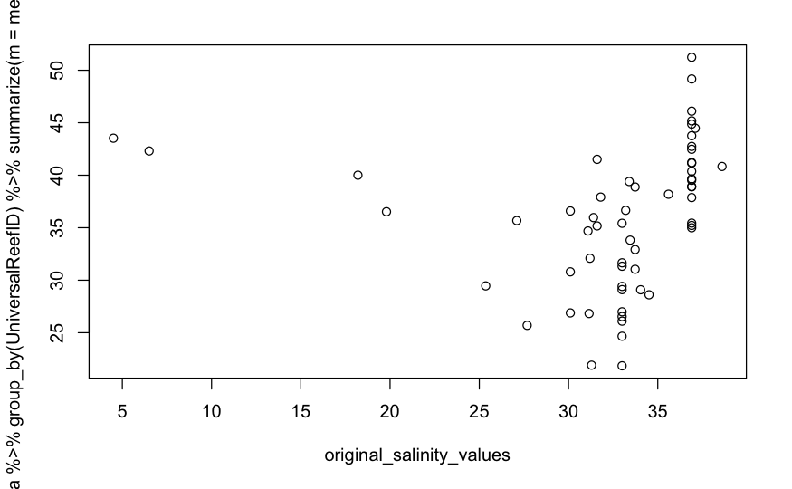

```r
plot(original_salinity_values, (Estero_Bay_Data%>% group_by(UniversalReefID) %>% summarize(m = mean(ShellHeight_mm)))$m)
```

Need stan code to use covariate Fit the Baysian model for Mean shell heights that vary by space; salinity is a covariate for each site Total execution time: 609.2 seconds

```r
Data = list( N =  nrow(Estero_Bay_Data)
             ,  y = Estero_Bay_Data$ShellHeight_mm
             , x = original_salinity_values #
             , G = max(Estero_Bay_Data$group)
             , group = Estero_Bay_Data$group
             , positions = (Estero_Bay_Data %>% dplyr::select(mean_lon, mean_lat, group) %>% distinct() %>% arrange(group))[,c("mean_lon","mean_lat")]
             )


spatial_RE.mod <- cmdstan_model("spatial_RE.stan") # allows a covariate on the site mean

 spatial_salinity_RE.EsteroBay.Shell_Height =  spatial_RE.mod$sample(
    data = Data,
    seed = 1111,
    chains = 4, # 8
    parallel_chains = 4, # 8
    refresh = 1000,
    iter_warmup = 5000,
    iter_sampling = 5000,
    thin =  1
    #, adapt_delta = 0.99
  )
```

Standard Deviation of posterior distribution of mean shell_height_mm estimate per site as a function of sample size

```r
sd_by_sample_size_covariate = data.frame(sample_size = (Estero_Bay_Data %>% group_by(UniversalReefID) %>% summarize( n = n()))$n, sd = spatial_mean_RE.EsteroBay.Shell_Height$summary("site_mean")$sd, sd_w_covariate = spatial_salinity_RE.EsteroBay.Shell_Height$summary("site_mean")$sd)
```

```r
sd_by_sample_size_covariate %>% ggplot(aes(x = sample_size, y = sd)) + geom_point()+ geom_smooth() + ggtitle("Estero Bay Shell Height")
```

[output not shown]

predict on the oyster positions

```r
#Prediction: draw from the relevant posterior distributions

source("SpatialPredictionUtilities.R")
alpha_covariate_posterior = spatial_salinity_RE.EsteroBay.Shell_Height$draws("sigma", format = "draws_matrix") # 4 chains 5000 draws after 5000 warmup
rho_covariate_posterior = spatial_salinity_RE.EsteroBay.Shell_Height$draws("length_scale", format = "draws_matrix")
obs_gp_function_posterior = spatial_salinity_RE.EsteroBay.Shell_Height$draws("gp_function", format = "draws_matrix")
obs_distances =  my_calc_point_distances(Data$positions)
pred_distances =  my_calc_point_distances(oyster_positions)
obs_to_pred_distances = my_calc_point_distances(Data$positions, oyster_positions)
slope_posterior = spatial_salinity_RE.EsteroBay.Shell_Height$draws("slope", format = "draws_matrix")
intercept_posterior = spatial_salinity_RE.EsteroBay.Shell_Height$draws("intercept", format = "draws_matrix")
#global_mean_posterior = spatial_mean_RE.EsteroBay.Shell_Height$draws("global_mean", format = "draws_matrix")
```

```r
mean_covariate_preds <- matrix(NA, nrow = 100, ncol = NROW(oyster_positions))
for(i in 1:NROW(mean_covariate_preds)){
  #cat('Processing posterior draw', i, 'of 5...\n')
  global_mean_covariate_posterior = intercept_posterior[i] + slope_posterior[i] *original_salinity_values
  mean_covariate_preds[i,] <- predict_covariate_mean(as.numeric(global_mean_covariate_posterior), obs_distances = obs_distances,
                             pred_distances = pred_distances,
                             obs_to_pred_distances = obs_to_pred_distances,
                             obs_gp_function = as.vector(as.matrix(obs_gp_function_posterior[i,])),
                             alpha = alpha_covariate_posterior[i],
                             rho = rho_covariate_posterior[i])
}
```